# 2 Frequency domain modeling

Author

Affiliation

[Aditya Mahajan](https://adityam.github.io)

[McGill University](http://www.mcgill.ca/ece)

Updated

November 26, 2026

## 2.1 Introduction

In this lecture, we will review frequency domain modeling of LTI systems. You have seen this material in Signals and Systems. The purpose of this review is to simply introduce the notation used in this course, in case it happens to be different from the notation used in Signals and Systems. You are strongly encouraged to review your notes on this topic.

**Note A comment about notation**

In Signals and Systems, we used $u(t)$ to denote the step function. In this course, we will use $u(t)$ to denote the control input. So, to avoid confusion, we will use $\IND(t)$ to denote the step function. *Note that the book uses $u(t)$, which can get confusing, in my opinion.*

## 2.2 Review: Unilateral Laplace Transforms

Recall that there are two types of Laplace transforms (LTs): bi-lateral or two-sided LTs and unilateral or one-sided LTs. In this course, we will work exclusively with unilateral LTs.

Also recall that for two-sided LTs, we need to worry about the ROC (region of convergence). For one-sided LTs, we never explicitly mention the ROC since it is always the right hand plane right to the rightmost pole.

We will use the notation
$$f(t) \xleftrightarrow{\quad\mathcal L\quad} F(s)$$
to denote a LT-pair. We will also use
$$F(s) = \mathcal{L}\{ f(t)\}$$
or
$$f(t) = \mathcal L^{-1}\{F(s)\}$$
when we want to explicitly write the LT or the inverse LT of a signal.

The basic formula for a unilateral LT is
$$F(s) = \int_{0-}^{\infty} f(t)e^{-st} dt.$$
The inverse Laplace transform is given by
$$f(t) = \frac{1}{2\pi j} \int_{\sigma - j \infty}^{\sigma + j \infty} F(s) e^{st} ds$$
where $\sigma$ is chosen such that $(\sigma,0)$ is in the ROC.

In this course, we will **never** explicitly use these formulas to compute LTs. We will **always** use LT tables. LT table for most commonly used functions is shown in Table 2.1. You do not need to memorize the LT table; one will be provided during the examples. What you do need is the understanding of how to use the LT tables to compute LTs of complicated expressions and to compute inverse LTs using partial fraction expansion.

Table 2.1: Laplace Transform Table

| **Signal $f(t)$** | **Laplace Transform $F(s)$** |
| --- | --- |
| $δ(t)$ | $1$ |
| $\IND(t)$ | $\dfrac 1s$ |
| $t\IND(t)$ | $\dfrac 1{s^2}$ |
| $t^n\IND(t)$ | $\dfrac {n!}{s^{n+1}}$ |
| $e^{-at}\IND(t)$ | $\dfrac 1{s+a}$ |
| $\sin ωt \IND(t)$ | $\dfrac{ω}{s^2 + ω^2}$ |
| $\cos ωt \IND(t)$ | $\dfrac{s}{s^2 + ω^2}$ |
| $A e^{-at} \cos ωt \IND(t)$ | $\dfrac{ A(s+a) }{ (s+a)^2 + ω^2 }$ |
| $B e^{-at} \sin ωt \IND(t)$ | $\dfrac{ B ω }{ (s+a)^2 + ω^2 }$ |

I will not review this material in class. Please go back to your SS notes or review Sec 2.1–2.2 of the textbook. It is important to understand the following three cases:

1. Roots of the denominator are real and distinct
2. Roots of the denominator are complex and distinct
3. Roots of the denominator are real and repeated.

## 2.3 The Transfer Function

Let’s start with an example. Consider a RLC circuit shown in Figure 2.1 with input voltage $u(t)$ and output voltage $v_C(t)$.

[figure not shown]

Figure 2.1: A simple RLC circuit

In your circuit courses, you have learnt, how to identify a differential equation that describes the relationship between the input and the output (assuming zero initial conditions).

**NoteDifferential equation for a circuit**

Summing all the voltages across the loop, we get that
$$v_R(t) + v_L(t) + v_C(t) = u(t)$$
Let $i(t)$ denote the loop current and $q(t)$ denote the charge across the capacitor. From basic circuit relationships, we know that $i(t) = dq(t)/dt$ and
$$v_R(t) = R i(t) = R \frac{dq(t)}{dt},
\quad
v_L(t) = L \frac{di(t)}{dt} = L \frac{d^2q(t)}{dt^2},
\quad
v_C(t) = \frac{1}{C} q(t).$$
Thus,
$$L \frac{d^2q(t)}{dt^2} + R \frac{dq(t)}{dt^2} + \frac{1}{C}q(t) = u(t).$$
Substituting $q(t) = C v_C(t)$, we get
$$LC \frac{d^2v_C(t)}{dt^2} + RC \frac{dv_C(t)}{dt^2} + v_C(t) = u(t).$$

As you know, circuits are an instance of an LTI system. In general, we will represent an LTI system with input $u(t)$ (also called the reference signal sometimes) and output $y(t)$ using the following block diagram:

[figure not shown]

Figure 2.2: An LTI System

As we saw for the RLC example, the input output relationship of an LTI system can be represented via a differential equation (using the notation $y(t) = v_C(t)$):
$$LC \frac{d^2y(t)}{dt^2} + RC \frac{dy(t)}{dt^2} + y(t) = u(t).$$
Such a differential equation is called a **constant coefficient linear differential equation (LDE)**.

- This differential equation is called **linear** because there are no non-linear or multiplicative terms of the form $\displaystyle \left(\frac{d^3 y(t)}{dt^3}\right)\left(\frac{d^2 y(t)}{dt^2}\right)$.
- It is called **constant coefficient** because the coefficients $a_n$ and $b_m$ are constants that do not depend on time.

In general, every LTI system can be described by a constant coefficient LDE and vice-versa. We will now show how to connect the LDE of an LTI system with its fudamental definiting property: **the inpulse reponse**, which we denote the $g(t)$.

Recall that the Laplace transform of $g(t)$, which we denote by $G(s)$, is called the **transfer function**. The key observation of this section is that we can identify the transfer function from the coefficients of the LDE simply by inspection.

### 2.3.1 Identifying trasnfer function from linear differential equations

Conisder an LTI system with input $u(t)$ and output $y(t)$. We know that
$$Y(s) = G(s)U(s).$$
We will use the following block diagram to denote this relationship.

[figure not shown]

Figure 2.3: An LTI System

If we know the input and output, we can identify the transfer function using
$$G(s) = \frac{Y(s)}{U(s)}.$$
Now, consider a general constant coefficient LDE of the form
$$a_n \frac{d^n y(t)}{dt^n} + a_{n-1} \frac{d^{n-1} y(t)}{dt^{n-1}} + \cdots a_0 y(t)
= b_m \frac{d^m u(t)}{dt^m} + b_{m-1} \frac{d^{m-1} u(t)}{dt^{m-1}} + \cdots + b_0 u(t).$$
and assume that the system starts from zero-initial state. Taking the LT of both sides, we get
$$a_n s^n Y(s) + a_{n-1} s^{n-1} Y(s) + \cdots + a_0 Y(s)
= b_m s^m U(s) + b_{m-1} s^{m-1} U(s) + \cdots + b_0 U(s).$$
Rearranging terms, we get
$$(a_n s^n + a_{n-1} s^{n-1} + \cdots + a_0) Y(s)
= (b_m s^m + b_{m-1}s^{m-1} + \cdots + b_0) U(s).$$
Therefore,
$$G(s) = \frac{Y(s)}{U(s)}
= \frac{b_m s^m + b_{m-1} s^{m-1} + \cdots + b_0}
{a_n s^n + a_{n-1} s^{n-1} + \cdots + a_0}.$$
Thus, we can easily go back and forth between the DE and the transfer function.

**Example 2.1** Consider the LDE
$$\frac{dy(t)}{dt} + 2 y(t) = u(t)$$

Find the transfer function:

\(\dfrac{1}{s+2}\)

\(s+2\)

\(2s+1\)

\(\dfrac{1}{2s + 1}\)

**Example 2.2** Consider the LDE
$$\frac{d^2 y(t)}{dt^2} + 3\frac{dy(t)}{dt} + 2 y(t) = 2\frac{du(t)}{dt} + u(t)$$

Find the transfer function:

\(\dfrac{1}{s^2 + 3s + 2}\)

\(\dfrac{2s + 1}{s^2 + 3s + 2}\)

\(\dfrac{2s + 1}{s^2 + 2s + 3}\)

\(\dfrac{s + 2}{s^2 + 3s + 2}\)

**Example 2.3** Consider the transfer function
$$G(s) = \frac{2s+1}{s^2 + 2s + 3}.$$

Find the LDE that implements the above TF:

\(\dfrac{d^2 y(t)}{dt^2} + 2\dfrac{dy(t)}{dt} + 3 y(t) = u(t)\)

\(\dfrac{d^2 y(t)}{dt^2} + 2\dfrac{dy(t)}{dt} + 3 y(t) = \dfrac{du(t)}{dt} + 2u(t)\)

\(\dfrac{d^2 y(t)}{dt^2} + 3\dfrac{dy(t)}{dt} + 2 y(t) = 2\dfrac{du(t)}{dt} + u(t)\)

\(\dfrac{d^2 y(t)}{dt^2} + 2\dfrac{dy(t)}{dt} + 3 y(t) = 2\dfrac{du(t)}{dt} + u(t)\)

In this course, we will assume that the system is specified either as a LDE or as a TF. The textbook provides detailed examples of how to derive either the LDE or the TF from a physical system such as an electric circuit or a spring-mass system. Later in the course we will also study other equivalent forms of representing the system such as state space equations and Bode plots.

A final remark. In all the systems that we consider in this course, we will assume that $m < n$. So, the denominator of the TF has a strictly higher degree than the numerator. Such transfer functions are called **proper**. It is possible to have causal systems where $m=n$ but we will not consider that in this course. As a consequence, when we consider state space representation in future lectures, we will get formulas which are simpler than more general formulas which you may find at other sources.

**WarningModeling real systems: Time delay systems**

In a real system, there is often a delay between input and output, which is often modeled by a delay block whose output $y(t)$ is a delayed version of the input $u(t)$, by a delay time $τ$, that is
$$y(t) = u(t-τ).$$
Taking the Laplace transform of both sides, we get
$$Y(s) = e^{-τs}U(s).$$
Therefore, the TF of time-delay unit is $e^{-τs}$, which is different from the TFs studied so far as it is not a rational polynomial of $s$. It is possible to approximate $e^{-τs}$ using a rational polynomial using what is called [**Padé approximation**](https://en.wikipedia.org/wiki/Pad%C3%A9_approximant):

- **First-order Padé approximation:**
  $$e^{-τs} \approx \dfrac{1 - τs/2}{1 + τs/2}.$$

- **Second-order Padé approximation:**
  $$e^{-τs} \approx \dfrac{1 - τs/2 + (τs)^2/12}{1 + τs/2 + (τs)^2/12}.$$

We will not study time-delay systems in the course.

### 2.3.2 Interconnection of LTI Systems

There are three common ways to interconnect LTI systems shown below.

[figure not shown]

Figure 2.4: Cascade Connection equivalent to $G_1(s)G_2(s)$.

[figure not shown]

Figure 2.5: Parallel Connection equivalent to $G_1(s) + G_2(s)$.

[figure not shown]

Figure 2.6: Feedback Connection equivalent to $\displaystyle \frac{G(s)}{1 + G(s)H(s)}$.

## 2.4 The Big Picture

However, in general, there are (often unmodeled) disturbances between the actuator and the plant, and also between the output and the feedback sensor, as shown in Figure 2.7.

[figure not shown]

Figure 2.7: A more complete model of feedback control system

In the above figure, we have

- $G(s)$: Plant transfer function
- $G_c(s)$: Controller transfer function
- $R(s)$: Reference input
- $Y(s)$: System Output
- $D_1(s)$, $D_2(s)$: Disturbances
- $E(s)$: Tracking error

These variables are related as follows:
$$\begin{align*}
Y(s) &= D_2(s) + G(s)( E(s) G_c(s) + D_1(s)), \\
E(s) &= R(s) - Y(s).
\end{align*}$$
Simplifying the above equations, we get
$$Y(s) = D_2(s) + R(s) G_c(s)G(s) - Y(s) G_c(s) G(s) + G(s)D_1(s).$$
Therefore,
$$\bbox[5pt,border: 1px solid]
{
Y(s) = \frac{G_c(s)G(s)}{1 + G_c(s)G(s)} R(s)
+ \frac{G(s)}{1 + G_c(s)G(s)} D_1(s)
+ \frac{1}{1 + G_c(s)G(s)} D_2(s)
}$$

Observe that if $G_c(s)$ is a constant that is very large, then
$$\begin{align*}
\lim_{G_c(s) \to \infty} \frac{G_c(s)G(s)}{1 + G_c(s)G(s)} R(s) &= R(s), \\
\lim_{G_c(s) \to \infty} \frac{G(s)}{1 + G_c(s)G(s)} D_1(s) &= 0, \\
\lim_{G_c(s) \to \infty} \frac{1}{1 + G_c(s)G(s)} D_2(s) &= 0.
\end{align*}$$
Thus,
$$\bbox[5pt,border: 1px solid]
{\text{In the limit $G_c(s) \to ∞$, $Y(s) = R(s)$}}$$

Thus, high gain can in principle achieve good tracking and disturbance rejection. However, as we will see in the subsequent lectures, there is a trade-off associated with choosing large control gains. To analyze when the closed loop is stable, and more generally, how controller choice affects closed-loop behavior, we need a compact description of transfer functions in terms of their roots. We develop this language next.

## 2.5 Pole-Zero Plots

The TF of an LTI system is always of the form:
$$G(s)
= \frac{b_m s^m + b_{m-1} s^{m-1} + \cdots + b_0}
{a_n s^n + a_{n-1} s^{n-1} + \cdots + a_0}.$$

Both the numerator and the denominator are polynomials in $s$. So, we can factorize them and write the TF as
$$G(s)
= K
\frac{(s-z_1)(s-z_2) \cdots (s - z_m)}
{(s-p_1)(s-p_2)\cdots (s-p_n)}.$$

- The roots of the numerator are called **zeros** (because $G(z_i) = 0$).
- The roots of the denominator are called **poles** (because $G(p_i) = \infty$ and if we plot $G(s)$ it will have a peak going to $∞$ at $p_i$; this peak looks like a pole).
- The constant $K$ is called the **gain** (because, when none of the poles and zeros are at origin, the step response of $G(s)$ will have a steady state value of $K$).

Returning to Section 2.4, each closed-loop transfer function from $R$, $D_1$, or $D_2$ to $Y$ has the same denominator $1 + G_c(s)G(s)$. The **poles** of these closed-loop transfer functions are therefore the roots of $1 + G_c(s)G(s) = 0$. Control design often amounts to choosing $G_c(s)$ so that these closed-loop poles lie in desirable locations—for example, in the open left half plane for stability, or further left for faster response.

We often represent the poles and zeros using a **pole-zero plot.**

[interactive chart not shown]

**Example 2.4 (Pole-zero plot)** Consider
$$G(s) = \frac{s+2}{(s+1)^2 + 1^2}.$$
The poles are $-1 \pm j$ and the zero is $-2$. The pole-zero plot is shown below, where the location of the pole is represented by a “cross” and the location of the zero is represented by a “circle”.

[interactive chart not shown]

Since the polynomials in the numerator and denominator of $G(s)$ have real coefficients, the roots are either real or occur in complex conjugate pairs. So, the poles and zeros either lie on the $σ$-axis or are symmetric about the $σ$-axis.

Note that the pole-zero plot does not capture the gain of the TF.

### 2.5.1 BIBO Stability

Recall from Signals and Systems that an LTI system with impulse response $g(t)$ is BIBO stable if
$$\int_{-∞}^{∞} |g(t)| dt < \infty.$$

For a causal system (i.e., a system for which $g(t) = 0$ for $t < 0$), this is equivalent to
$$\int_{0^{-}}^{∞} |g(t)| dt < ∞.$$

This implies that for any $σ \in \reals$, $σ > 0$, we have
$$\int_{0^{-}}^{∞} |g(t)| e^{-σt} dt < ∞.$$

Therefore, there can be no pole in the open right hand plane $\{ (σ + j ω) : σ > 0 \}$. Thus, we have the following:

> A causal LTI system is stable if all poles are in the open left hand plane.

[interactive chart not shown]

(a) Stable systems

[interactive chart not shown]

(b) Unstable systems

[interactive chart not shown]

(c) Marginally stable systems

[interactive chart not shown]

(d) Unstable systems (double pole at origin)

Figure 2.8: Illustration of stable and unstable systems

If there are poles on the $j ω$ axis and the poles have multiplicity 1, then the system is **marginally stable**; if poles have multiplicity greater than 1, then the system is unstable.

**Example 2.5** Consider the transfer function
$$G(s) = \frac{2}{(s-1)(s+5)}.$$

Is this system BIBO stable?

Yes

No

**Example 2.6** Consider the transfer function
$$G(s) = \frac{1}{(s+2)(s^2 + 2s + 5)}.$$

Is this system BIBO stable?

Yes

No

**Example 2.7** Consider the transfer function
$$G(s) = \frac{1}{(s+1)(s^2 + 4)}.$$

Is this system BIBO stable?

Yes

No

### 2.5.2 Step Response

One of the configurations that we will really focus on in the course is the output of a *stable* system when the **input is a step function.** This is often the case when we specify a reference input such as the desired temperature of a room or the desired speed in cruise control of a car, and are interested in seeing if we get a “good” output. Note that this question is only of interest for stable systems. If the system is unstable, then the output will go to infinity.

As an example, consider the system of Example 2.1. What is the output when the input is a step function (assuming that the system starts from a zero initial state)?

To compute this, recall
$$\IND(t) \xleftrightarrow{\quad \mathcal L\quad} \frac 1s.$$

Thus, $U(s) = 1/s$. We had already identified that $G(s) = 1/(s+2)$. Thus,
$$\begin{align*}
Y(s) &= G(s) U(s) \\
&= \frac{1}{s(s+2)} \\
&= \frac{ \frac 12 }{s} - \frac{ \frac 12 }{ s + 2 }
\quad \text{[By partial fraction expansion]}.
\end{align*}$$
Thus,
$$y(t) = \left[ \frac 12 - \frac 12 e^{-2t} \right] \IND(t).$$

We can verify this by simulation.[^1]

<sup>1</sup> In the lab, we will use Matlab for simulating LTI systems. However, in the course notes, I use Julia which makes it easier to directly include the output in a webpage.

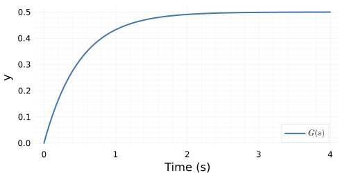

```julia
using ControlSystems, Plots

G = zpk([], [-2], 1)
T = 4

plot(step(G, T), label=L"G(s)", size=(500,250))
```

In the next lecture, we will see how to use the poles to identify the step response of the system.

## Exercises

**Exercise 2.1** Find the Laplace transform for the following signals:

1. $\frac{1}{2} e^{-2t} \IND(t) + \frac{1}{3}e^{-3t} \IND(t)$.
2. $-\frac{1}{2} e^{2t} \IND(t) + \frac{1}{3}e^{-3t} \IND(t)$.
3. $\frac{1}{2} e^{2t} \IND(t) - \frac{1}{3}e^{3t} \IND(t)$.
4. $\frac{1}{2} e^{-2t} \IND(t) + \frac{1}{3}e^{3t} \IND(t)$.

**Exercise 2.2** Using partial fraction expansion, find the inverse Laplace transform of the following.

1. $\dfrac{s+1}{s^2 + 2s}$
2. $\dfrac{s^2 + 1}{s^3 + 2s^2}$
3. $\dfrac{s+3}{(s+5)(s^2 + 4s + 5)}$

**Exercise 2.3** Consider the system described by the following differential equation:
$$\frac{d^2 y(t)}{dt^2} + 4 \frac{dy(t)}{dt} + 8 y(t)
= \frac{du(t)}{dt} + 4u(t).$$

1. Identify the system transfer function.
2. Using Laplace transforms, find step response of the system.